# Risk Factor Analysis

## Outcome Variable

**Outcome Variable:** s03rec24

## Predictor Variables

**Intervention Variable:** earlybf

**Adjustment Set:**

- arm
- sex
- brthmon
- W_mage
- meducyrs
- feducyrs
- hfoodsec
- W_mhtcm
- W_mwtkg
- W_mbmi
- W_birthwt
- single
- W_nrooms
- impfloor
- impsan
- delta_W_mage
- delta_meducyrs
- delta_feducyrs
- delta_hfoodsec
- delta_W_mhtcm
- delta_W_mwtkg
- delta_W_mbmi
- delta_W_birthwt
- delta_single
- delta_W_nrooms
- delta_impfloor
- delta_impsan

## Stratifying Variables

The analysis was stratified on these variable(s):

- studyid
- country

## Data Summary

| studyid | country | earlybf | s03rec24 | n_cell | n |
| --- | --- | --- | --- | --- | --- |
| ki0047075b-MAL-ED | BANGLADESH | 0 | 0 | 91 | 246 |
| ki0047075b-MAL-ED | BANGLADESH | 0 | 1 | 7 | 246 |
| ki0047075b-MAL-ED | BANGLADESH | 1 | 0 | 147 | 246 |
| ki0047075b-MAL-ED | BANGLADESH | 1 | 1 | 1 | 246 |
| ki0047075b-MAL-ED | BRAZIL | 0 | 0 | 107 | 223 |
| ki0047075b-MAL-ED | BRAZIL | 0 | 1 | 10 | 223 |
| ki0047075b-MAL-ED | BRAZIL | 1 | 0 | 98 | 223 |
| ki0047075b-MAL-ED | BRAZIL | 1 | 1 | 8 | 223 |
| ki0047075b-MAL-ED | INDIA | 0 | 0 | 93 | 245 |
| ki0047075b-MAL-ED | INDIA | 0 | 1 | 5 | 245 |
| ki0047075b-MAL-ED | INDIA | 1 | 0 | 139 | 245 |
| ki0047075b-MAL-ED | INDIA | 1 | 1 | 8 | 245 |
| ki0047075b-MAL-ED | NEPAL | 0 | 0 | 132 | 238 |
| ki0047075b-MAL-ED | NEPAL | 0 | 1 | 8 | 238 |
| ki0047075b-MAL-ED | NEPAL | 1 | 0 | 95 | 238 |
| ki0047075b-MAL-ED | NEPAL | 1 | 1 | 3 | 238 |
| ki0047075b-MAL-ED | PERU | 0 | 0 | 63 | 284 |
| ki0047075b-MAL-ED | PERU | 0 | 1 | 7 | 284 |
| ki0047075b-MAL-ED | PERU | 1 | 0 | 202 | 284 |
| ki0047075b-MAL-ED | PERU | 1 | 1 | 12 | 284 |
| ki0047075b-MAL-ED | SOUTH AFRICA | 0 | 0 | 102 | 287 |
| ki0047075b-MAL-ED | SOUTH AFRICA | 0 | 1 | 9 | 287 |
| ki0047075b-MAL-ED | SOUTH AFRICA | 1 | 0 | 166 | 287 |
| ki0047075b-MAL-ED | SOUTH AFRICA | 1 | 1 | 10 | 287 |
| ki0047075b-MAL-ED | TANZANIA, UNITED REPUBLIC OF | 0 | 0 | 42 | 253 |
| ki0047075b-MAL-ED | TANZANIA, UNITED REPUBLIC OF | 0 | 1 | 0 | 253 |
| ki0047075b-MAL-ED | TANZANIA, UNITED REPUBLIC OF | 1 | 0 | 210 | 253 |
| ki0047075b-MAL-ED | TANZANIA, UNITED REPUBLIC OF | 1 | 1 | 1 | 253 |
| ki1000109-EE | PAKISTAN | 0 | 0 | 274 | 350 |
| ki1000109-EE | PAKISTAN | 0 | 1 | 0 | 350 |
| ki1000109-EE | PAKISTAN | 1 | 0 | 76 | 350 |
| ki1000109-EE | PAKISTAN | 1 | 1 | 0 | 350 |
| ki1113344-GMS-Nepal | NEPAL | 0 | 0 | 748 | 1084 |
| ki1113344-GMS-Nepal | NEPAL | 0 | 1 | 14 | 1084 |
| ki1113344-GMS-Nepal | NEPAL | 1 | 0 | 308 | 1084 |
| ki1113344-GMS-Nepal | NEPAL | 1 | 1 | 14 | 1084 |

The following strata were considered:

- studyid: ki0047075b-MAL-ED, country: BANGLADESH
- studyid: ki0047075b-MAL-ED, country: BRAZIL
- studyid: ki0047075b-MAL-ED, country: INDIA
- studyid: ki0047075b-MAL-ED, country: NEPAL
- studyid: ki0047075b-MAL-ED, country: PERU
- studyid: ki0047075b-MAL-ED, country: SOUTH AFRICA
- studyid: ki0047075b-MAL-ED, country: TANZANIA, UNITED REPUBLIC OF
- studyid: ki1000109-EE, country: PAKISTAN
- studyid: ki1113344-GMS-Nepal, country: NEPAL

### Dropped Strata

Some strata were dropped due to rare outcomes:

- studyid: ki0047075b-MAL-ED, country: BANGLADESH
- studyid: ki0047075b-MAL-ED, country: NEPAL
- studyid: ki0047075b-MAL-ED, country: TANZANIA, UNITED REPUBLIC OF
- studyid: ki1000109-EE, country: PAKISTAN

## Methods Detail

We’re interested in the causal parameters $E[Y_a]$ for all values of $a \in \mathcal{A}$. These parameters represent the mean outcome if, possibly contrary to fact, we intervened to set all units to have $A=a$. Under the randomization and positivity assumptions, these are identified by the statistical parameters $\psi_a=E_W[E_{Y|A,W}(Y|A=a,W)]$. In addition, we’re interested in the mean of $Y$, $E[Y]$ under no intervention (the observed mean). We will estimate these parameters by using SuperLearner to fit the relevant likelihood factors – $E_{Y|A,W}(Y|A=a,W)$ and $p(A=a|W)$, and then updating our likelihood fit using a joint TMLE.

For unadjusted analyses ($W=\{\}$), initial likelihoods were estimated using Lrnr_glm to estimate the simple $E(Y|A)$ and Lrnr_mean to estimate $p(A)$. For adjusted analyses, a small library containing Lrnr_glmnet, Lrnr_xgboost, and Lrnr_mean was used.

Having estimated these parameters, we will then use the delta method to estimate relative risks and attributable risks relative to a prespecified baseline level of $A$.

# Results Detail

## Results Plots

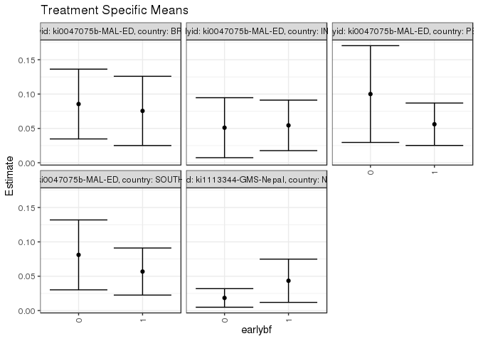

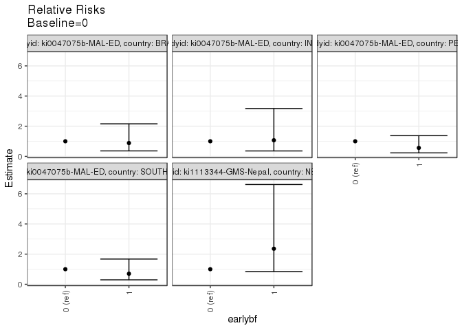

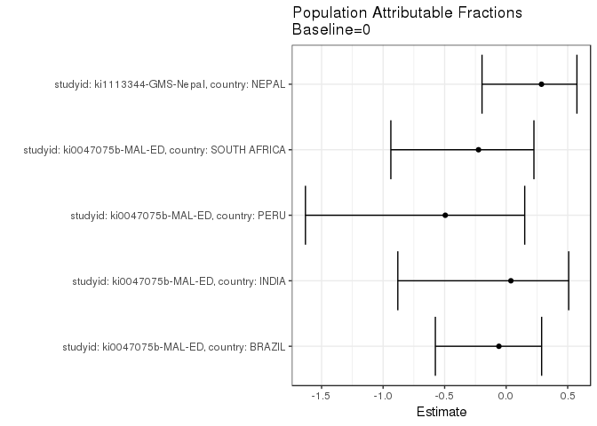

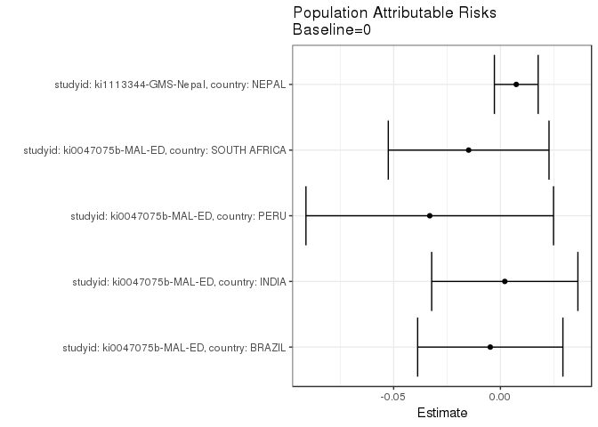

## Results Table

### Parameter: TSM

| studyid | country | intervention_level | baseline_level | estimate | ci_lower | ci_upper |
| --- | --- | --- | --- | --- | --- | --- |
| ki0047075b-MAL-ED | BRAZIL | 0 | NA | 0.0854701 | 0.0346966 | 0.1362436 |
| ki0047075b-MAL-ED | BRAZIL | 1 | NA | 0.0754717 | 0.0250725 | 0.1258709 |
| ki0047075b-MAL-ED | INDIA | 0 | NA | 0.0510204 | 0.0073665 | 0.0946744 |
| ki0047075b-MAL-ED | INDIA | 1 | NA | 0.0544218 | 0.0176756 | 0.0911680 |
| ki0047075b-MAL-ED | PERU | 0 | NA | 0.1000000 | 0.0295978 | 0.1704022 |
| ki0047075b-MAL-ED | PERU | 1 | NA | 0.0560748 | 0.0251960 | 0.0869535 |
| ki0047075b-MAL-ED | SOUTH AFRICA | 0 | NA | 0.0810811 | 0.0302133 | 0.1319489 |
| ki0047075b-MAL-ED | SOUTH AFRICA | 1 | NA | 0.0568182 | 0.0225579 | 0.0910785 |
| ki1113344-GMS-Nepal | NEPAL | 0 | NA | 0.0184143 | 0.0048858 | 0.0319427 |
| ki1113344-GMS-Nepal | NEPAL | 1 | NA | 0.0434063 | 0.0119501 | 0.0748625 |

### Parameter: E(Y)

| studyid | country | intervention_level | baseline_level | estimate | ci_lower | ci_upper |
| --- | --- | --- | --- | --- | --- | --- |
| ki0047075b-MAL-ED | BRAZIL | NA | NA | 0.0807175 | 0.0448848 | 0.1165502 |
| ki0047075b-MAL-ED | INDIA | NA | NA | 0.0530612 | 0.0249356 | 0.0811869 |
| ki0047075b-MAL-ED | PERU | NA | NA | 0.0669014 | 0.0377918 | 0.0960110 |
| ki0047075b-MAL-ED | SOUTH AFRICA | NA | NA | 0.0662021 | 0.0373865 | 0.0950177 |
| ki1113344-GMS-Nepal | NEPAL | NA | NA | 0.0258303 | 0.0124633 | 0.0391972 |

### Parameter: RR

| studyid | country | intervention_level | baseline_level | estimate | ci_lower | ci_upper |
| --- | --- | --- | --- | --- | --- | --- |
| ki0047075b-MAL-ED | BRAZIL | 0 | 0 | 1.0000000 | 1.0000000 | 1.000000 |
| ki0047075b-MAL-ED | BRAZIL | 1 | 0 | 0.8830189 | 0.3612498 | 2.158402 |
| ki0047075b-MAL-ED | INDIA | 0 | 0 | 1.0000000 | 1.0000000 | 1.000000 |
| ki0047075b-MAL-ED | INDIA | 1 | 0 | 1.0666667 | 0.3586487 | 3.172402 |
| ki0047075b-MAL-ED | PERU | 0 | 0 | 1.0000000 | 1.0000000 | 1.000000 |
| ki0047075b-MAL-ED | PERU | 1 | 0 | 0.5607477 | 0.2293999 | 1.370697 |
| ki0047075b-MAL-ED | SOUTH AFRICA | 0 | 0 | 1.0000000 | 1.0000000 | 1.000000 |
| ki0047075b-MAL-ED | SOUTH AFRICA | 1 | 0 | 0.7007576 | 0.2935365 | 1.672914 |
| ki1113344-GMS-Nepal | NEPAL | 0 | 0 | 1.0000000 | 1.0000000 | 1.000000 |
| ki1113344-GMS-Nepal | NEPAL | 1 | 0 | 2.3572101 | 0.8398741 | 6.615800 |

### Parameter: PAR

| studyid | country | intervention_level | baseline_level | estimate | ci_lower | ci_upper |
| --- | --- | --- | --- | --- | --- | --- |
| ki0047075b-MAL-ED | BRAZIL | 0 | NA | -0.0047526 | -0.0387647 | 0.0292595 |
| ki0047075b-MAL-ED | INDIA | 0 | NA | 0.0020408 | -0.0321964 | 0.0362780 |
| ki0047075b-MAL-ED | PERU | 0 | NA | -0.0330986 | -0.0910685 | 0.0248713 |
| ki0047075b-MAL-ED | SOUTH AFRICA | 0 | NA | -0.0148790 | -0.0525136 | 0.0227556 |
| ki1113344-GMS-Nepal | NEPAL | 0 | NA | 0.0074160 | -0.0028303 | 0.0176623 |

### Parameter: PAF

| studyid | country | intervention_level | baseline_level | estimate | ci_lower | ci_upper |
| --- | --- | --- | --- | --- | --- | --- |
| ki0047075b-MAL-ED | BRAZIL | 0 | NA | -0.0588794 | -0.5754307 | 0.2883054 |
| ki0047075b-MAL-ED | INDIA | 0 | NA | 0.0384615 | -0.8804848 | 0.5083416 |
| ki0047075b-MAL-ED | PERU | 0 | NA | -0.4947368 | -1.6311467 | 0.1508500 |
| ki0047075b-MAL-ED | SOUTH AFRICA | 0 | NA | -0.2247511 | -0.9370836 | 0.2256322 |
| ki1113344-GMS-Nepal | NEPAL | 0 | NA | 0.2871052 | -0.1961503 | 0.5751211 |